# FaceNewsIntervention - Data Analysis

## self-identified political ideology (independent/predictor) & MIST COVID (dprime Pre-test) (dependent/outcome)

```r
m <- lm(MIST_dprime_Pretest_covid ~ poly(Political_LiberalConservative, 2),
        data=filter(df, !is.na(Political_LiberalConservative)))

display(parameters(m))
```

| Parameter | Coefficient | SE | 95% CI | t(261) | p |
| --- | --- | --- | --- | --- | --- |
| (Intercept) | 0.42 | 0.04 | (0.34, 0.50) | 9.90 | < .001 |
| Political LiberalConservative (1st degree) | -2.68 | 0.69 | (-4.04, -1.33) | -3.90 | < .001 |
| Political LiberalConservative (2nd degree) | -0.22 | 0.69 | (-1.58, 1.13) | -0.32 | 0.747 |

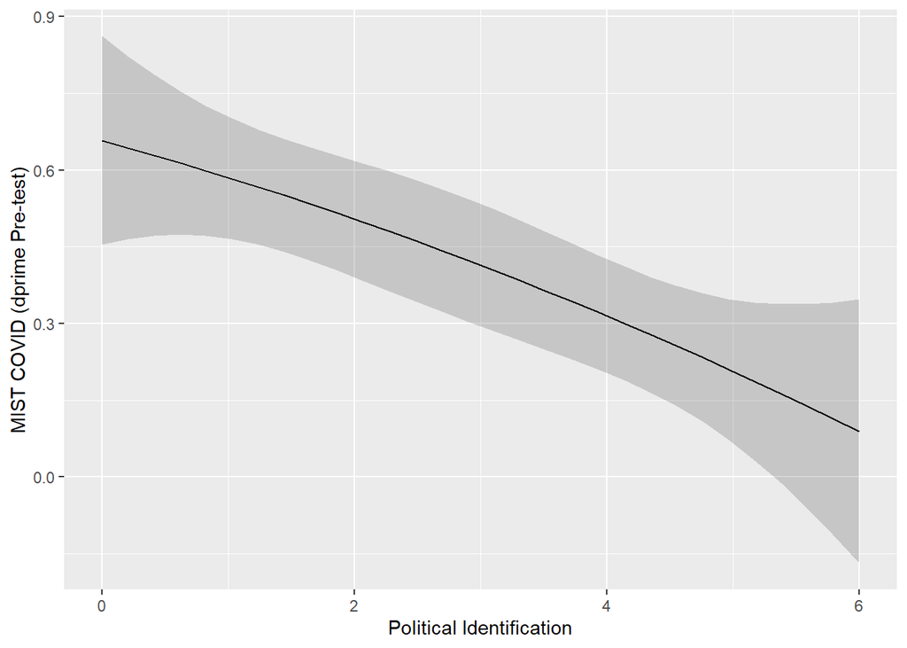

```r
estimate_relation(m, length=30) |>
  ggplot(aes(x=Political_LiberalConservative, y=Predicted)) +
  # geom_jitter(data=filter(df, !is.na(Political_LiberalConservative)),
  #             aes(y=MIST_correct_Pretest_covid), alpha=0.2, size=3) +
  geom_ribbon(aes(ymin=CI_low, ymax=CI_high), alpha=0.2) +
  geom_line() +
  labs(y="MIST COVID (dprime Pre-test)", x="Political Identification")
```

## self-identified political ideology (independent/predictor) & MIST General (% Correct Pre-test) (dependent/outcome)

```r
m <- lm(MIST_correct_Pretest_general ~ poly(Political_LiberalConservative, 2),
        data=filter(df, !is.na(Political_LiberalConservative)))

display(parameters(m))
```

| Parameter | Coefficient | SE | 95% CI | t(261) | p |
| --- | --- | --- | --- | --- | --- |
| (Intercept) | 0.65 | 7.95e-03 | (0.64, 0.67) | 82.26 | < .001 |
| Political LiberalConservative (1st degree) | -0.69 | 0.13 | (-0.95, -0.44) | -5.36 | < .001 |
| Political LiberalConservative (2nd degree) | -0.07 | 0.13 | (-0.32, 0.18) | -0.54 | 0.588 |

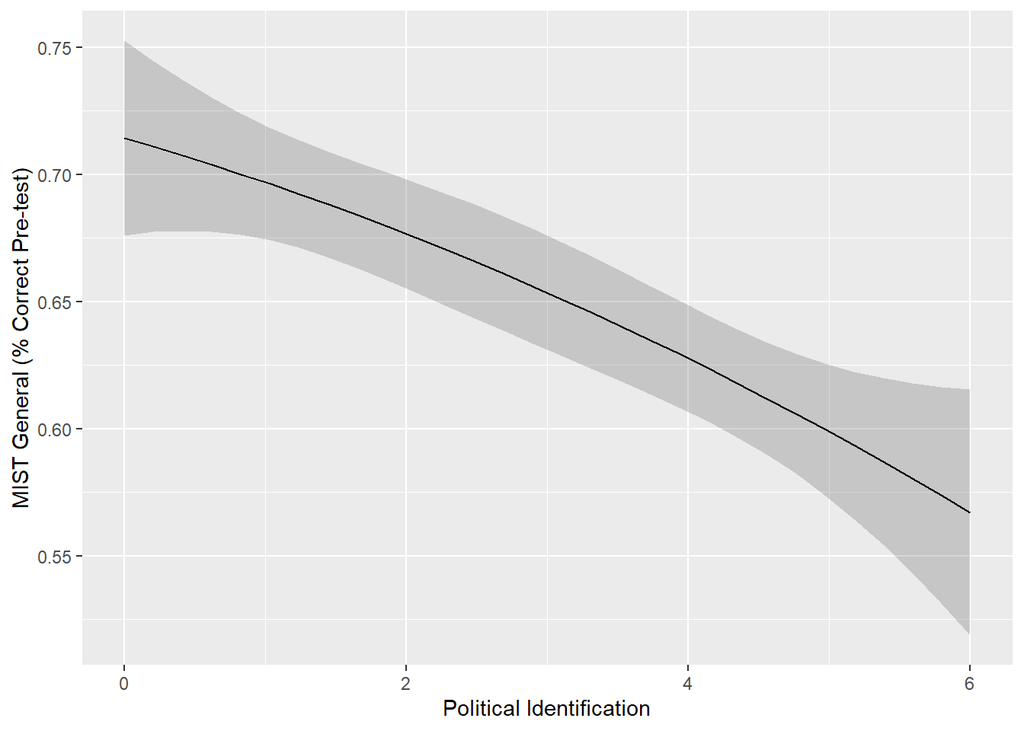

```r
estimate_relation(m, length=30) |>
  ggplot(aes(x=Political_LiberalConservative, y=Predicted)) +
  # geom_jitter(data=filter(df, !is.na(Political_LiberalConservative)),
  #             aes(y=MIST_correct_Pretest_covid), alpha=0.2, size=3) +
  geom_ribbon(aes(ymin=CI_low, ymax=CI_high), alpha=0.2) +
  geom_line() +
  labs(y="MIST General (% Correct Pre-test)", x="Political Identification")
```

## self-identified political ideology (independent/predictor) & MIST General (dprime Pre-test) (dependent/outcome)

```r
m <- lm(MIST_dprime_Pretest_general ~ poly(Political_LiberalConservative, 2),
        data=filter(df, !is.na(Political_LiberalConservative)))

display(parameters(m))
```

| Parameter | Coefficient | SE | 95% CI | t(261) | p |
| --- | --- | --- | --- | --- | --- |
| (Intercept) | 0.93 | 0.05 | (0.84, 1.02) | 20.58 | < .001 |
| Political LiberalConservative (1st degree) | -4.60 | 0.73 | (-6.05, -3.16) | -6.27 | < .001 |
| Political LiberalConservative (2nd degree) | -0.21 | 0.73 | (-1.65, 1.24) | -0.28 | 0.778 |

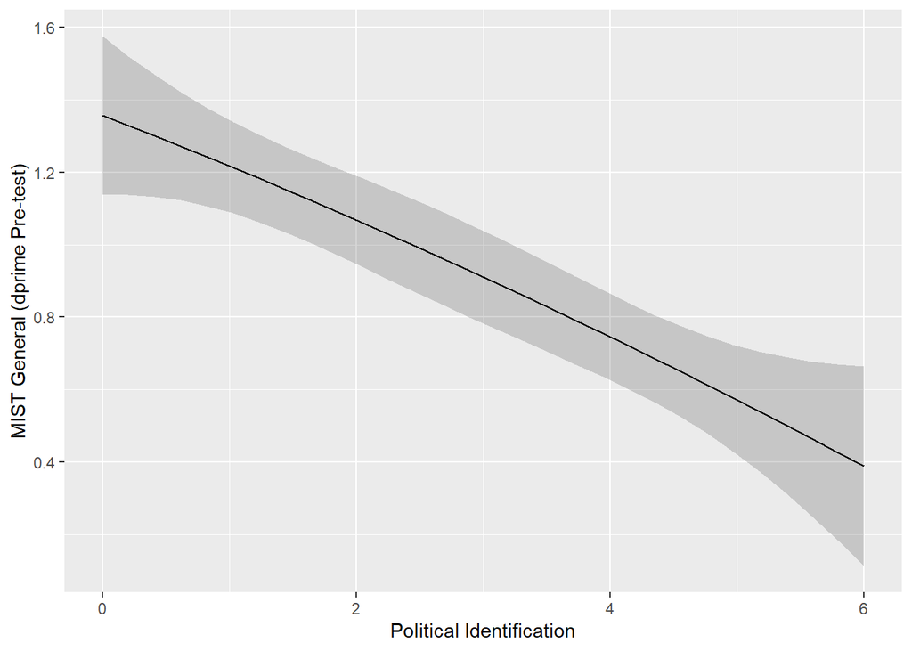

```r
estimate_relation(m, length=30) |>
  ggplot(aes(x=Political_LiberalConservative, y=Predicted)) +
  # geom_jitter(data=filter(df, !is.na(Political_LiberalConservative)),
  #             aes(y=MIST_correct_Pretest_covid), alpha=0.2, size=3) +
  geom_ribbon(aes(ymin=CI_low, ymax=CI_high), alpha=0.2) +
  geom_line() +
  labs(y="MIST General (dprime Pre-test)", x="Political Identification")
```

## self-identified political ideology (independent/predictor) & MIST General (% Correct difference Post-Pre) (dependent/outcome)

```r
m <- lm(MIST_correct_Diff_general ~ poly(Political_LiberalConservative, 2),
        data=filter(df, !is.na(Political_LiberalConservative)))

display(parameters(m))
```

| Parameter | Coefficient | SE | 95% CI | t(261) | p |
| --- | --- | --- | --- | --- | --- |
| (Intercept) | 4.08e-03 | 7.38e-03 | (-0.01, 0.02) | 0.55 | 0.581 |
| Political LiberalConservative (1st degree) | 0.04 | 0.12 | (-0.20, 0.28) | 0.34 | 0.735 |
| Political LiberalConservative (2nd degree) | -0.15 | 0.12 | (-0.38, 0.09) | -1.22 | 0.222 |

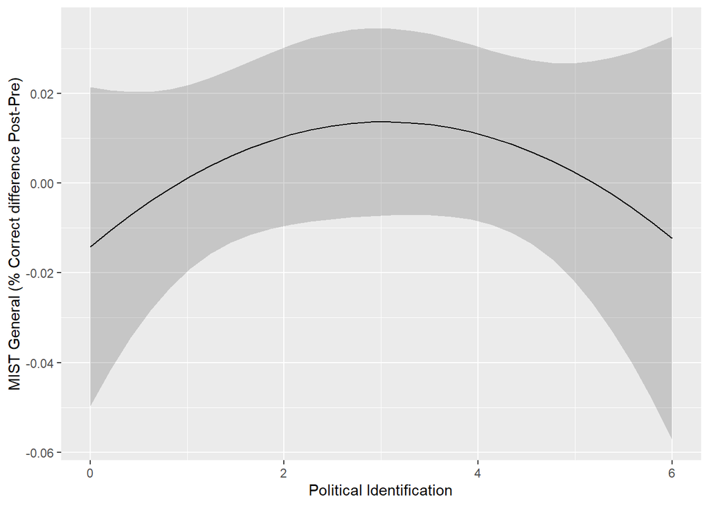

```r
estimate_relation(m, length=30) |>
  ggplot(aes(x=Political_LiberalConservative, y=Predicted)) +
  # geom_jitter(data=filter(df, !is.na(Political_LiberalConservative)),
  #             aes(y=MIST_correct_Pretest_covid), alpha=0.2, size=3) +
  geom_ribbon(aes(ymin=CI_low, ymax=CI_high), alpha=0.2) +
  geom_line() +
  labs(y="MIST General (% Correct difference Post-Pre)", x="Political Identification")
```

## self-identified political ideology (independent/predictor) & MIST General (dprime difference Post-Pre) (dependent/outcome)

```r
m <- lm(MIST_dprime_Diff_general ~ poly(Political_LiberalConservative, 2),
        data=filter(df, !is.na(Political_LiberalConservative)))

display(parameters(m))
```

| Parameter | Coefficient | SE | 95% CI | t(261) | p |
| --- | --- | --- | --- | --- | --- |
| (Intercept) | 0.06 | 0.04 | (-0.03, 0.15) | 1.32 | 0.187 |
| Political LiberalConservative (1st degree) | 0.33 | 0.73 | (-1.11, 1.76) | 0.45 | 0.654 |
| Political LiberalConservative (2nd degree) | -0.95 | 0.73 | (-2.39, 0.48) | -1.31 | 0.192 |

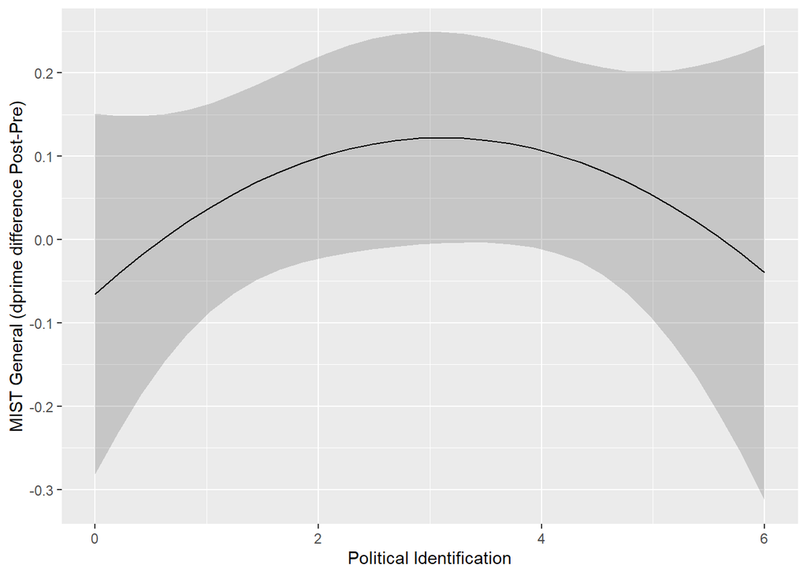

```r
estimate_relation(m, length=30) |>
  ggplot(aes(x=Political_LiberalConservative, y=Predicted)) +
  # geom_jitter(data=filter(df, !is.na(Political_LiberalConservative)),
  #             aes(y=MIST_correct_Pretest_covid), alpha=0.2, size=3) +
  geom_ribbon(aes(ymin=CI_low, ymax=CI_high), alpha=0.2) +
  geom_line() +
  labs(y="MIST General (dprime difference Post-Pre)", x="Political Identification")
```

## self-identified political ideology (independent/predictor) & MIST COVID (% Correct difference Post-Pre) (dependent/outcome)

```r
m <- lm(MIST_correct_Diff_covid ~ poly(Political_LiberalConservative, 2),
        data=filter(df, !is.na(Political_LiberalConservative)))

display(parameters(m))
```

| Parameter | Coefficient | SE | 95% CI | t(261) | p |
| --- | --- | --- | --- | --- | --- |
| (Intercept) | 2.27e-03 | 0.01 | (-0.02, 0.03) | 0.19 | 0.849 |
| Political LiberalConservative (1st degree) | 0.16 | 0.19 | (-0.22, 0.54) | 0.83 | 0.409 |
| Political LiberalConservative (2nd degree) | 0.09 | 0.19 | (-0.29, 0.47) | 0.47 | 0.639 |

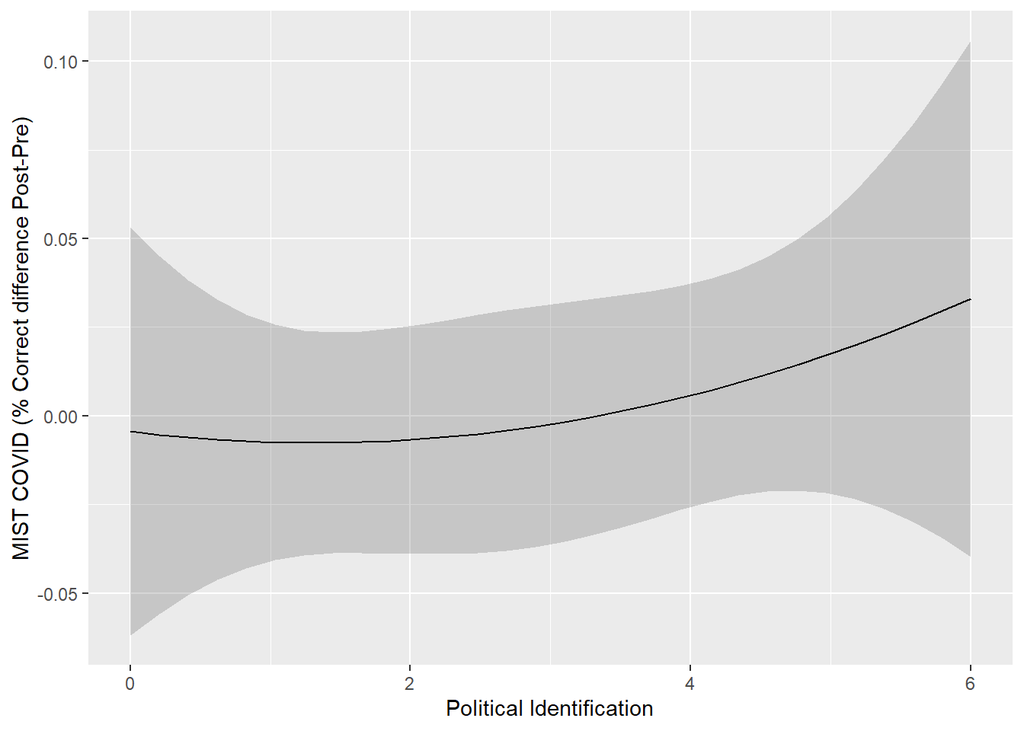

```r
estimate_relation(m, length=30) |>
  ggplot(aes(x=Political_LiberalConservative, y=Predicted)) +
  # geom_jitter(data=filter(df, !is.na(Political_LiberalConservative)),
  #             aes(y=MIST_correct_Pretest_covid), alpha=0.2, size=3) +
  geom_ribbon(aes(ymin=CI_low, ymax=CI_high), alpha=0.2) +
  geom_line() +
  labs(y="MIST COVID (% Correct difference Post-Pre)", x="Political Identification")
```

## self-identified political ideology (independent/predictor) & MIST COVID (dprime difference Post-Pre) (dependent/outcome)

```r
m <- lm(MIST_dprime_Diff_covid ~ poly(Political_LiberalConservative, 2),
        data=filter(df, !is.na(Political_LiberalConservative)))

display(parameters(m))
```

| Parameter | Coefficient | SE | 95% CI | t(261) | p |
| --- | --- | --- | --- | --- | --- |
| (Intercept) | 0.02 | 0.06 | (-0.10, 0.15) | 0.37 | 0.711 |
| Political LiberalConservative (1st degree) | 0.56 | 1.05 | (-1.50, 2.62) | 0.53 | 0.596 |
| Political LiberalConservative (2nd degree) | 0.47 | 1.05 | (-1.59, 2.53) | 0.45 | 0.657 |

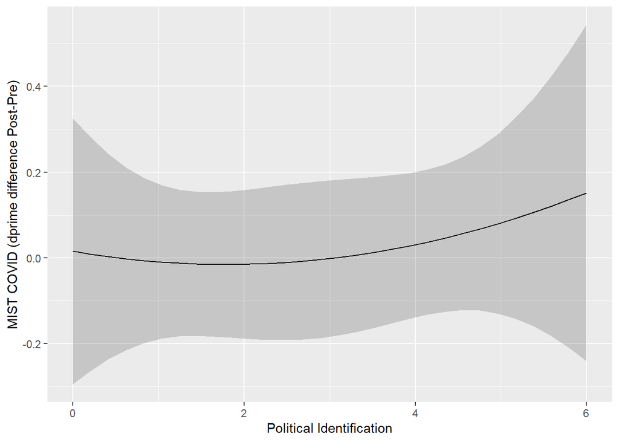

```r
estimate_relation(m, length=30) |>
  ggplot(aes(x=Political_LiberalConservative, y=Predicted)) +
  # geom_jitter(data=filter(df, !is.na(Political_LiberalConservative)),
  #             aes(y=MIST_correct_Pretest_covid), alpha=0.2, size=3) +
  geom_ribbon(aes(ymin=CI_low, ymax=CI_high), alpha=0.2) +
  geom_line() +
  labs(y="MIST COVID (dprime difference Post-Pre)", x="Political Identification")
```

## self-identified political ideology (independent/predictor) & MIST TOTAL (% Correct difference Post-Pre) (dependent/outcome)

```r
m <- lm(MIST_correct_Diff ~ poly(Political_LiberalConservative, 2),
        data=filter(df, !is.na(Political_LiberalConservative)))

display(parameters(m))
```

| Parameter | Coefficient | SE | 95% CI | t(261) | p |
| --- | --- | --- | --- | --- | --- |
| (Intercept) | 3.17e-03 | 7.29e-03 | (-0.01, 0.02) | 0.44 | 0.664 |
| Political LiberalConservative (1st degree) | 0.10 | 0.12 | (-0.13, 0.33) | 0.85 | 0.397 |
| Political LiberalConservative (2nd degree) | -0.03 | 0.12 | (-0.26, 0.21) | -0.24 | 0.814 |

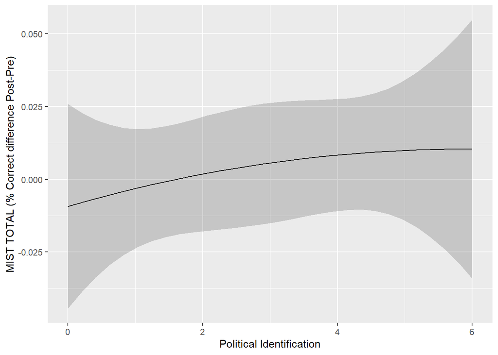

```r
estimate_relation(m, length=30) |>
  ggplot(aes(x=Political_LiberalConservative, y=Predicted)) +
  # geom_jitter(data=filter(df, !is.na(Political_LiberalConservative)),
  #             aes(y=MIST_correct_Pretest_covid), alpha=0.2, size=3) +
  geom_ribbon(aes(ymin=CI_low, ymax=CI_high), alpha=0.2) +
  geom_line() +
  labs(y="MIST TOTAL (% Correct difference Post-Pre)", x="Political Identification")
```

## self-identified political ideology (independent/predictor) & MIST TOTAL (dprime difference Post-Pre) (dependent/outcome)

```r
m <- lm(MIST_dprime_Diff ~ poly(Political_LiberalConservative, 2),
        data=filter(df, !is.na(Political_LiberalConservative)))

display(parameters(m))
```

| Parameter | Coefficient | SE | 95% CI | t(261) | p |
| --- | --- | --- | --- | --- | --- |
| (Intercept) | 0.04 | 0.04 | (-0.04, 0.12) | 1.02 | 0.308 |
| Political LiberalConservative (1st degree) | 0.44 | 0.66 | (-0.86, 1.74) | 0.67 | 0.506 |
| Political LiberalConservative (2nd degree) | -0.24 | 0.66 | (-1.55, 1.06) | -0.37 | 0.713 |

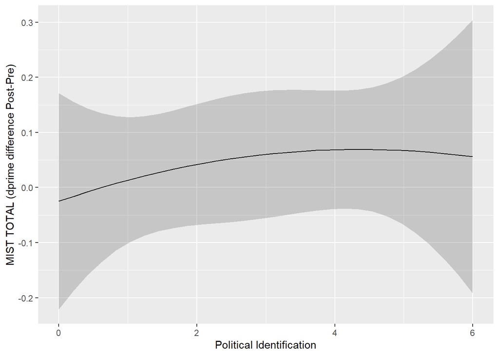

```r
estimate_relation(m, length=30) |>
  ggplot(aes(x=Political_LiberalConservative, y=Predicted)) +
  # geom_jitter(data=filter(df, !is.na(Political_LiberalConservative)),
  #             aes(y=MIST_correct_Pretest_covid), alpha=0.2, size=3) +
  geom_ribbon(aes(ymin=CI_low, ymax=CI_high), alpha=0.2) +
  geom_line() +
  labs(y="MIST TOTAL (dprime difference Post-Pre)", x="Political Identification")
```

## self-identified political ideology (independent/predictor) & MOCRI Pre-test correct (dependent/outcome)

```r
m <- lm(MOCRI_correct_Pre ~ poly(Political_LiberalConservative, 2),
        data=filter(df, !is.na(Political_LiberalConservative)))

display(parameters(m))
```

| Parameter | Coefficient | SE | 95% CI | t(261) | p |
| --- | --- | --- | --- | --- | --- |
| (Intercept) | 0.36 | 7.58e-03 | (0.35, 0.38) | 47.61 | < .001 |
| Political LiberalConservative (1st degree) | -0.37 | 0.12 | (-0.62, -0.13) | -3.04 | 0.003 |
| Political LiberalConservative (2nd degree) | -0.24 | 0.12 | (-0.48, 2.52e-03) | -1.95 | 0.052 |

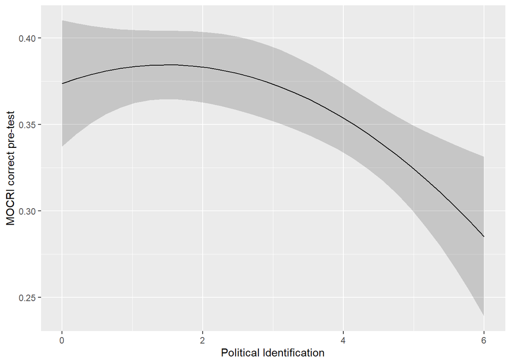

```r
estimate_relation(m, length=30) |>
  ggplot(aes(x=Political_LiberalConservative, y=Predicted)) +
  # geom_jitter(data=filter(df, !is.na(Political_LiberalConservative)),
  #             aes(y=MIST_correct_Pretest_covid), alpha=0.2, size=3) +
  geom_ribbon(aes(ymin=CI_low, ymax=CI_high), alpha=0.2) +
  geom_line() +
  labs(y="MOCRI correct pre-test", x="Political Identification")
```

## self-identified political ideology (independent/predictor) & MOCRI Pre-test dprime (dependent/outcome)

```r
m <- lm(MOCRI_dprime_Pre ~ poly(Political_LiberalConservative, 2),
        data=filter(df, !is.na(Political_LiberalConservative)))

display(parameters(m))
```

| Parameter | Coefficient | SE | 95% CI | t(261) | p |
| --- | --- | --- | --- | --- | --- |
| (Intercept) | 1.20 | 0.06 | (1.09, 1.31) | 21.38 | < .001 |
| Political LiberalConservative (1st degree) | -2.45 | 0.91 | (-4.25, -0.66) | -2.69 | 0.008 |
| Political LiberalConservative (2nd degree) | -2.37 | 0.91 | (-4.16, -0.57) | -2.59 | 0.010 |

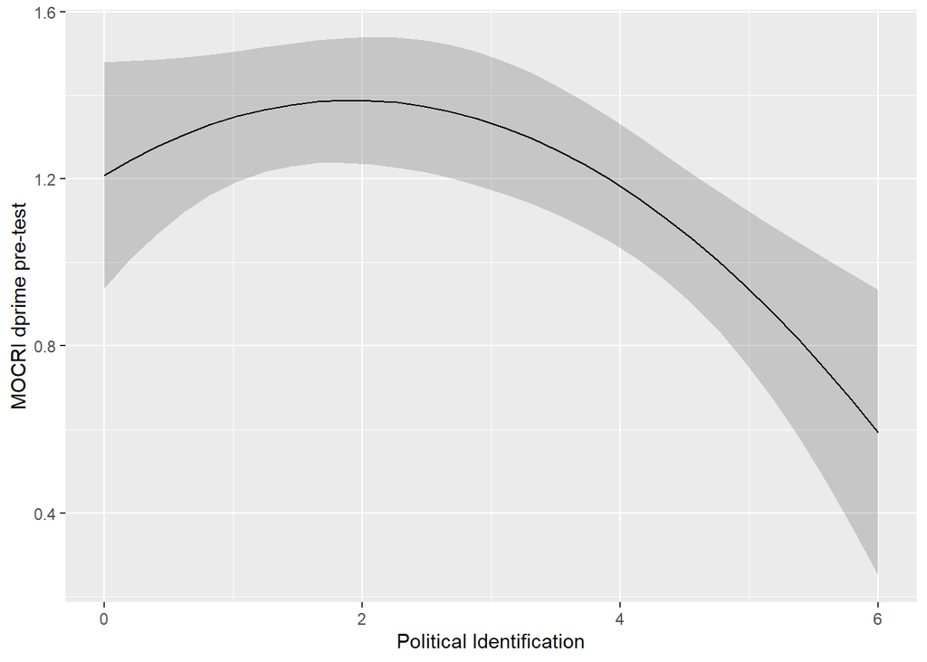

```r
estimate_relation(m, length=30) |>
  ggplot(aes(x=Political_LiberalConservative, y=Predicted)) +
  # geom_jitter(data=filter(df, !is.na(Political_LiberalConservative)),
  #             aes(y=MIST_correct_Pretest_covid), alpha=0.2, size=3) +
  geom_ribbon(aes(ymin=CI_low, ymax=CI_high), alpha=0.2) +
  geom_line() +
  labs(y="MOCRI dprime pre-test", x="Political Identification")
```

## self-identified political ideology (independent/predictor) & MOCRI difference dprime post-pre (dependent/outcome)

```r
m <- lm(MOCRI_dprime_Diff ~ poly(Political_LiberalConservative, 2),
        data=filter(df, !is.na(Political_LiberalConservative)))

display(parameters(m))
```

| Parameter | Coefficient | SE | 95% CI | t(261) | p |
| --- | --- | --- | --- | --- | --- |
| (Intercept) | 0.33 | 0.06 | (0.20, 0.45) | 5.05 | < .001 |
| Political LiberalConservative (1st degree) | -2.15 | 1.05 | (-4.21, -0.08) | -2.05 | 0.042 |
| Political LiberalConservative (2nd degree) | 0.49 | 1.05 | (-1.58, 2.55) | 0.46 | 0.643 |

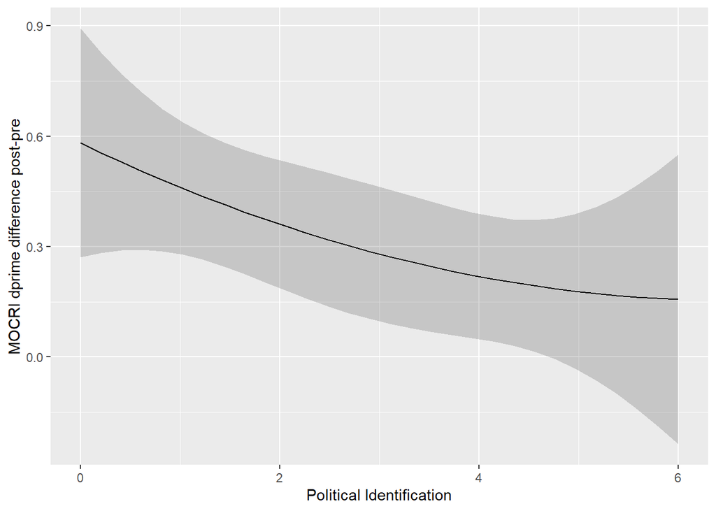

```r
estimate_relation(m, length=30) |>
  ggplot(aes(x=Political_LiberalConservative, y=Predicted)) +
  # geom_jitter(data=filter(df, !is.na(Political_LiberalConservative)),
  #             aes(y=MIST_correct_Pretest_covid), alpha=0.2, size=3) +
  geom_ribbon(aes(ymin=CI_low, ymax=CI_high), alpha=0.2) +
  geom_line() +
  labs(y="MOCRI dprime difference post-pre", x="Political Identification")
```

## self-identified political ideology (independent/predictor) & MOCRI difference correct post-pre (dependent/outcome)

```r
m <- lm(MOCRI_correct_Diff ~ poly(Political_LiberalConservative, 2),
        data=filter(df, !is.na(Political_LiberalConservative)))

display(parameters(m))
```

| Parameter | Coefficient | SE | 95% CI | t(261) | p |
| --- | --- | --- | --- | --- | --- |
| (Intercept) | 0.04 | 7.48e-03 | (0.02, 0.05) | 4.85 | < .001 |
| Political LiberalConservative (1st degree) | -0.14 | 0.12 | (-0.38, 0.10) | -1.14 | 0.256 |
| Political LiberalConservative (2nd degree) | 0.06 | 0.12 | (-0.18, 0.30) | 0.49 | 0.625 |

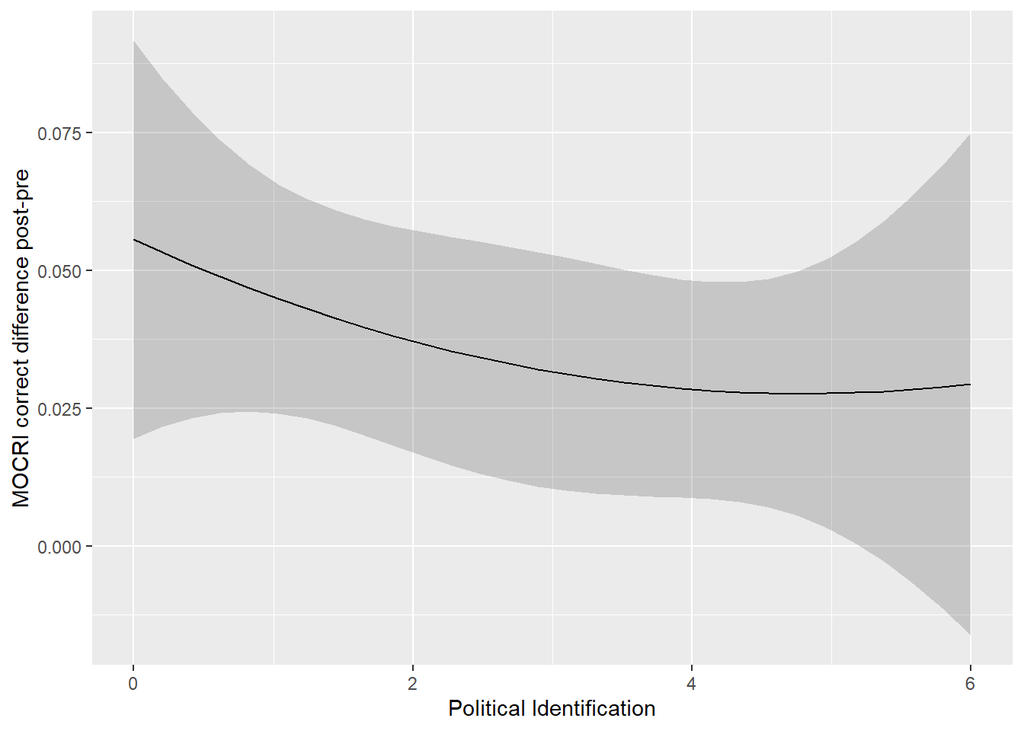

```r
estimate_relation(m, length=30) |>
  ggplot(aes(x=Political_LiberalConservative, y=Predicted)) +
  # geom_jitter(data=filter(df, !is.na(Political_LiberalConservative)),
  #             aes(y=MIST_correct_Pretest_covid), alpha=0.2, size=3) +
  geom_ribbon(aes(ymin=CI_low, ymax=CI_high), alpha=0.2) +
  geom_line() +
  labs(y="MOCRI correct difference post-pre", x="Political Identification")
```

## Gender (independent/predictor) & MIST COVID (% Correct difference post-pre) (dependent/outcome)

```r
# Categorical
df$Gender <- as.factor(df$Gender)
m <- lm(MIST_correct_Diff_covid ~ Gender,
        data=filter(df, Gender != "Non-Binary" & Gender != "Prefer not to answer"))


display(estimate_contrasts(m, contrast="Gender", p_adjust="none"))
```

Marginal Contrasts Analysis

| Level1 | Level2 | Difference | 95% CI | SE | t(258) | p |
| --- | --- | --- | --- | --- | --- | --- |
| Man | Woman | -0.03 | (-0.08, 0.01) | 0.02 | -1.39 | 0.167 |

Marginal contrasts estimated at Gender p-values are uncorrected.

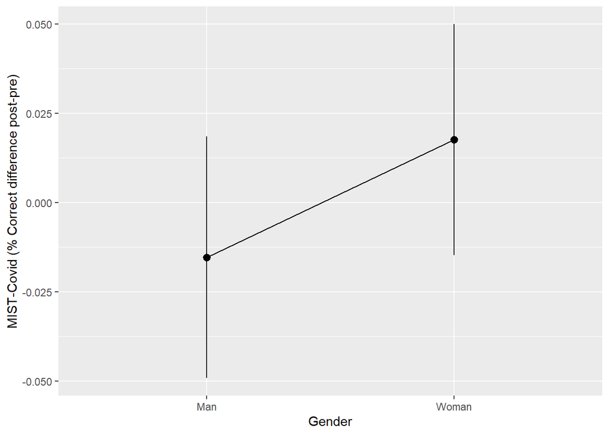

```r
estimate_means(m, by = c("Gender")) |>
  ggplot(aes(x=Gender, y=Mean)) +
  geom_line(aes(group=1)) +
  geom_pointrange(aes(ymin=CI_low, ymax=CI_high)) +
  labs(y="MIST-Covid (% Correct difference post-pre)", x="Gender")
```